# GCP Harmonization Tables & Figures

Author

Doug Tommet

Published

August 19, 2022

**Note**

- We adapted an in-person cognitive assessment battery for administration by two alternative modes: telephone and videoconference, in an on-going observational study of cognitive aging and delirium
- We administered all three modes (in-person, telephone, videoconference) in an on-going observational study of older surgical patients.
- We co-calibrated the scores across mode using item response theory (we placed the scores on the same metric)
- We compare the measurement precision (reliability) by mode:
- We contrast the external predictive (and postdictive) validity by mode (association with age, education, and mean change after surgery).

# Differences in GCP from the previous version

There were several different ways we considered harmonizing the test batteries to account for some mistakes and questionable assumptions.

The mistake was when we categorized the test scores into bins, the top two categories were combined into the same bin.

- Tests this issue affected: VSAT, HVLT total, HVLT delayed and Digit symbol substitution

The questionable assumptions were deciding whether measures of letter fluency and semantic fluency were equivalent. For letter fluency there were three options we considered and for semantic fluency there were two options we considered.

- Letter fluency:
  - FAS and FCL summed and deemed equivalent
  - FAS and FCL as individual tests, F are deemed equivalent, the other letters are not deemed equivalent
  - FAS and FCL summed but **not** deemed equivalent
- Semantic fluency:
  - Animal naming and supermarket item naming are deemed equivalent
  - Animal naming and supermarket item naming are **not** deemed equivalent

With these as the possible choices, we decided to go with the version that fixes the coding mistakes, FAS/FCL summed but not equivalent and animal/supermarket naming not equivalent.

## Figure 1: Timeline of SAGES-I and SAGES-II

[output not shown]

Figure 1: Timeline of SAGES-I and SAGES-II and the development/roll-out of novel assessment modes

Figure 1 is meant to show the development/refinement of the neuropsych testing procedures due to COVID.

**Note**

This needs to be sketched out by Eva/Tamara/Field staff.

## Table 1: Sample characteristics

Table 1: Sample characteristics

| **Characteristic** | **N = 420**<sup>1</sup> |
| --- | --- |
| Female Sex | 271 / 420 (65%) |
| Non white | 52 / 418 (12%) |
| Unknown | 2 |
| vdeduc_r | 16.25 (2.67) |
| Unknown | 1 |
| Surgery Type |  |
| 1 | 210 / 419 (50%) |
| 2 | 160 / 419 (38%) |
| 3 | 1 / 419 (0.2%) |
| 5 | 27 / 419 (6.4%) |
| 6 | 10 / 419 (2.4%) |
| 7 | 3 / 419 (0.7%) |
| 8 | 8 / 419 (1.9%) |
| Unknown | 1 |
| Geriatric Depression Scale Score [0-15] | 2.47 (2.31) |
| Charlson Comorbidity Index |  |
| 0 | 160 / 284 (56%) |
| 1 | 51 / 284 (18%) |
| 2 | 38 / 284 (13%) |
| 3 | 17 / 284 (6.0%) |
| 4 | 6 / 284 (2.1%) |
| 5 | 7 / 284 (2.5%) |
| 6 | 1 / 284 (0.4%) |
| 8 | 2 / 284 (0.7%) |
| 9 | 2 / 284 (0.7%) |
| Unknown | 136 |

<sup>1</sup> n / N (%); Mean (SD)

**Note**

This is the descriptive statistics for SAGES II at the baseline interview. In the harmonization analysis, for the telephone/video samples the interviews came (mostly) from the follow-up interviews.

## Table 2: Cognitive tests by mode and study

Table 2: Cognitive tests by mode and study

| item_label | Study/Mode HRS_ADAMS | Study/Mode SAGES | Study/Mode SAGESII_Inperson | Study/Mode SAGESII_Telephone | Study/Mode SAGESII_Video |
| --- | --- | --- | --- | --- | --- |
| Attention/Executive Function |  |  |  |  |  |
| Trails A (time, deciles) | X | X | X |  | X |
| Digit Span Forward | X | X | X | X | X |
| Digit Span Backward | X | X | X | X | X |
| Symbol Digit Modalities | X |  |  |  |  |
| Visual Search and Attention Task (VSAT) number of targets (octile) |  | X | X |  | X |
| Digit Symbol Substitution (aka rbans) (octile) |  | X | X |  | X |
| Oral Trails A Telephone Time to complete |  |  |  | X |  |
| Trails B (time, deciles) | X | X | X |  | X |
| Oral Trails B Telephone Time to complete |  |  |  | X |  |
| Language |  |  |  |  |  |
| CERAD Animal Fluency | X |  |  |  |  |
| Boston Naming Test, 15 Items | X | X | X |  | X |
| Letter fluency CFL (Controlled Oral Word Association Test (COWAT)) | X |  |  |  |  |
| Semantic fluency - supermarket (SAGES deciles) |  | X | X | X | X |
| Letter Fluency (FAS) (Sages deciles) |  | X | X | X | X |
| Category switching (Total number of correct switches) |  |  |  | X |  |
| Memory |  |  |  |  |  |
| CERAD sum of learning trials nonile | X |  |  |  |  |
| CERAD Delayed Word Recall, percent nonile | X |  |  |  |  |
| HVLT Trial 1-3 nonile (not nonile) |  | X | X | X | X |
| HVLT Delayed Recall Percent (octile) |  | X | X | X | X |

Table 2 shows the neuropsych tests used in the different studys/modes.

## Figure 2: Test Information by mode and study

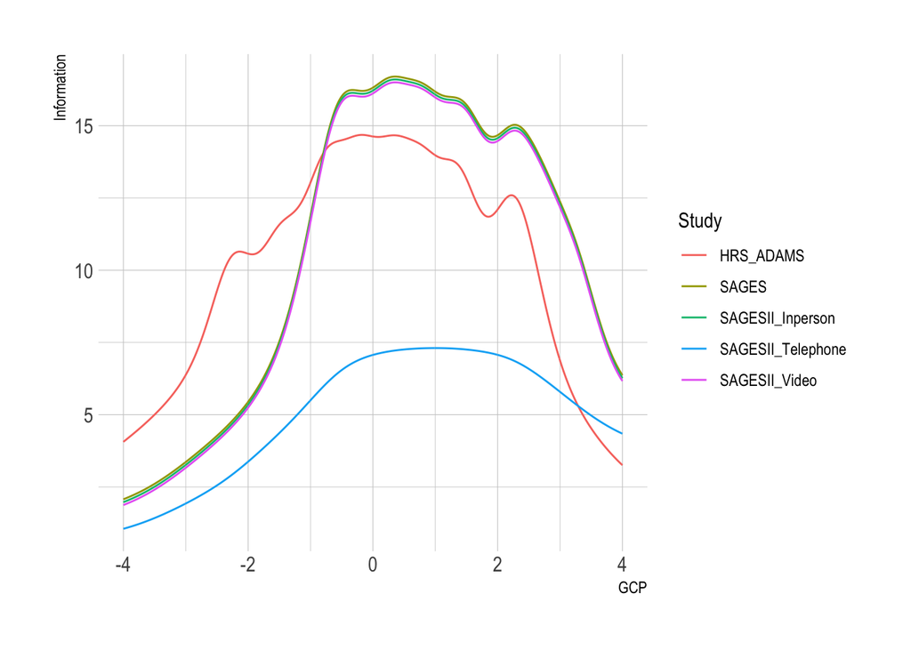

Figure 2: Test Information by mode and study

Figure 2 shows the information plot.

**Note**

The cognitive test battery was the same for SAGES I - In-person, SAGES II - In-person, and SAGES II - Video. This means their Information curves would overlap. I shifted the curves by a small amount so they would be distinct.

## Figure 3: Agreement by mode

Table 3 shows the results of Deming regression of telephone and video interview modes.

Table 3: Deming regression results

| EST | LCI | UCI |
| --- | --- | --- |
| 11.44 | −0.03 | 21.48 |
| 0.83 | 0.67 | 1.00 |

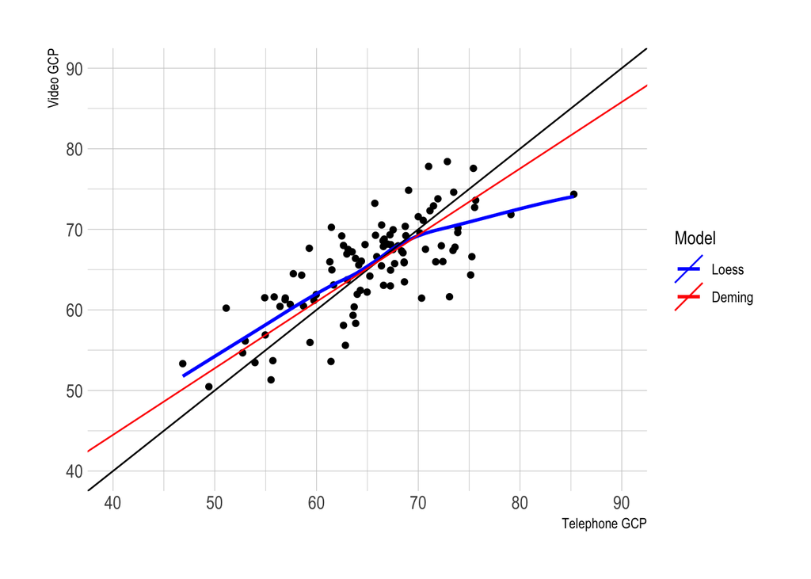

Figure 3: Scatterplot of Telephone vs Video GCP in validation sample

The correlation of GCP between telephone and video interviews is: 0.75.

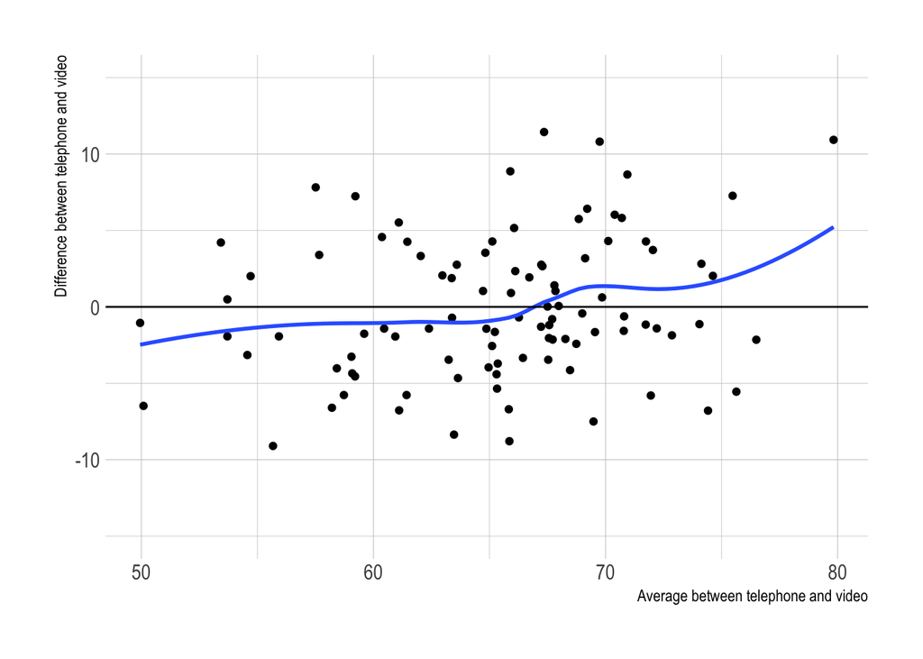

Figure 4: Bland-Altman plot of Telephone vs Video GCP in validation sample

## Figure 5: GCP by study

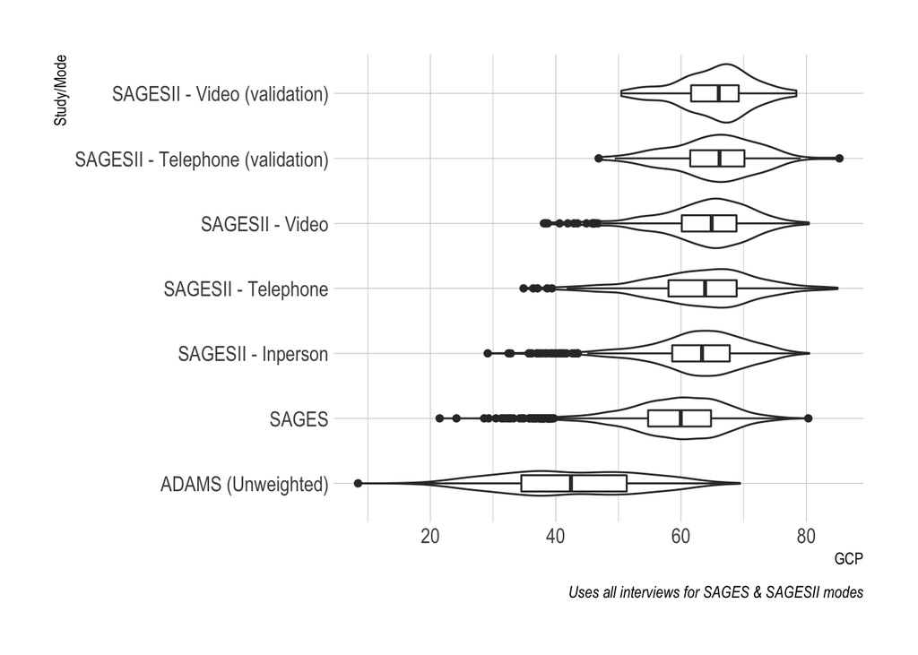

Figure 5: GCP by study/mode